# depth_first

### Graphs

Graphs are structures that present a number of nodes (or vertexes) connected by a number of edges.

G = (V,E), V = Vertices, E = Edges Each edge e in E is a pair of vertices: e = (u,v)

The amount of memory we need, Naïve representation: list of edges, O(|V|+|E|) memory. In the example below, we used an undirected graphs where there is no notion of a direction to any of the edges.

```python
import numpy as np
import networkx as nx
import matplotlib.pyplot as plt
%matplotlib inline
```

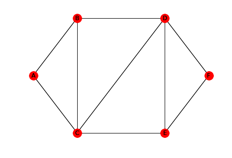

```python
graph = {'A': ['B', 'C'],
         'B': ['A', 'C', 'D'],
         'C': ['A', 'B', 'D', 'E'],
         'D': ['B', 'C', 'E', 'F'],
         'E': ['C', 'D', 'F'],
         'F': ['D', 'E']}

Graph = nx.Graph()
for node in graph:
    Graph.add_nodes_from(node)
    for edge in graph[node]:
        Graph.add_edge(node, edge)

pos = { 'A': [0.00, 0.50], 'B': [0.25, 0.75],
        'C': [0.25, 0.25], 'D': [0.75, 0.75],
        'E': [0.75, 0.25], 'F': [1.00, 0.50]}
nx.draw(Graph, pos, with_labels=True)
nx.draw_networkx(Graph, pos)
plt.show()
```

### Depth First Search

Depth First Search is another algorithm for searching a graph. When given the input graph = G(V,E) and a source vertex s, it begins at the source vertex and then explores a path all the way down to the end. Once it reaches the end, it backtracks and explores other paths within the current path that it hasn't searched yet, until it reaches the source vertex again. If there are other paths from the source that still haven't been searched, then the algorithm will choose one and search it. A depth first search allows for each path to be completely searched before searching any other path.

```python
def dfs(graph, start):
    stack = [start]
    parents = {start: start}
    path = list()
    while stack:
        print('Stack is: %s' % stack)
        vertex = stack.pop(-1)
        print('Processing %s' % vertex)
        for candidate in graph[vertex]:
            if candidate not in parents:
                parents[candidate] = vertex
                stack.append(candidate)
                print('Adding %s to the stack' % candidate)
        path.append(parents[vertex]+'>'+vertex)
    return path[1:]

steps = dfs(graph, 'A')
print('\nDFS:', steps)
```

```
Stack is: ['A']
Processing A
Adding B to the stack
Adding C to the stack
Stack is: ['B', 'C']
Processing C
Adding D to the stack
Adding E to the stack
Stack is: ['B', 'D', 'E']
Processing E
Adding F to the stack
Stack is: ['B', 'D', 'F']
Processing F
Stack is: ['B', 'D']
Processing D
Stack is: ['B']
Processing B

DFS: ['A>C', 'C>E', 'E>F', 'C>D', 'A>B']
```